# Validate E-MTAB-7183 AMD Eye Hits

Kendrix

2020-09-26

Aim: To validate AMD-associated hits that found by [Porter et al.](https://clinicalepigeneticsjournal.biomedcentral.com/articles/10.1186/s13148-019-0608-2#rightslink).

Pre-processing script adapted from Chaini Konwar.

```r
library(GEOquery)
library(RCurl)
library(GEOmetadb)
library(dendextend)
library(ArrayExpress)
library(methylumi)
library(lumi)
library(lattice)
library(gplots)
library(RColorBrewer)
library(limma)
library(ROC)
library(matrixStats)
library(reshape)
library(sva)
library(grid)
library(gridExtra)
library(ape)
library(Hmisc)
library(RCurl)
library(wateRmelon)
library(minfiData)
library(minfi)
library(robustHD)
library(ewastools)
library(omicsPrint)
library(doParallel)
library(jcolors)
library(plyr)
library(tidyverse)
library(ggrepel)
library(ggpubr)
library(IlluminaHumanMethylationEPICanno.ilm10b2.hg19)
library(IlluminaHumanMethylationEPICmanifest)
library(IlluminaHumanMethylation450kanno.ilmn12.hg19)
library(IlluminaHumanMethylation450kmanifest)
library(FlowSorted.Blood.EPIC)
library(FlowSorted.Blood.450k)
library(FlowSorted.CordBloodCombined.450k)
library(Biobase)
library(data.table)
library(factoextra)
library(Metrics)
library(quantro)
library(impute)

setwd("~/KoborLab/kobor_space/kendrix/macular_degeneration/")
```

## Data exploration and object creation

### Step 1: Explore data downloaded from ArrayExpress.

The data used here comes from [Whole-genome methylation profiling of the retinal pigment epithelium of individuals with age-related macular degeneration reveals differential methylation of the SKI, GTF2H4, and TNXB genes by *Porter et al.*](https://clinicalepigeneticsjournal.biomedcentral.com/articles/10.1186/s13148-019-0608-2#rightslink).

The authors made the dataset publicly available in ArrayExpress with the Accession number: E-MTAB-7183.

The dataset consists of ocular tissue (pigmented layer of retina) from 25 AMD samples (21 level 2 AMD and 4 level 3 AMD) and 19 controls.

The age ranges from 50 years old to 89 years old, and the sex distribution is as follows: Male (27), Female (17).

```r
#Explore metadata.
AMD_meta <- read.table("~/KoborLab/kobor_space/kendrix/macular_degeneration/data/E-MTAB-7183_meta.txt", sep = "\t", header = TRUE)
colnames(AMD_meta)[1] <- "Sample_Name"
colnames(AMD_meta)[3] <- "Sex"
colnames(AMD_meta)[4] <- "Age"
colnames(AMD_meta)[6] <- "Tissue"
colnames(AMD_meta)[7] <- "Disease_state"
colnames(AMD_meta)[17] <- "Assay_name"

AMD_meta$Sex <- gsub("male", "M", gsub("female", "F", AMD_meta$Sex)) #Changed for easier comparison with minfi sex prediction.

#Create samplesheet.
AMD_samplesheet <- AMD_meta[, c("Sample_Name", "Disease_state", "Assay_name", "Sex", "Age", "Tissue")]
colnames(AMD_samplesheet)[2] <- "Sample_Group"
AMD_samplesheet$Assay_name <- gsub("_Grn", "", gsub("_Red", "", AMD_samplesheet$Assay_name))
AMD_samplesheet <- separate(AMD_samplesheet, col = "Assay_name", sep = "_", into = c("Sentrix_ID", "Sentrix_Position"))

duplicated(AMD_samplesheet) #The samplesheet contains duplicated samples.
AMD_samplesheet <- AMD_samplesheet[duplicated(AMD_samplesheet),] #Remove duplicated samples.
```

```r
write.csv(AMD_samplesheet, file = "~/KoborLab/kobor_space/kendrix/macular_degeneration/data/idats/AMD_project/AMD_samplesheet.csv", row.names = FALSE)
```

### Step 2: Create ExtendedRGSet object.

```r
path = "~/KoborLab/kobor_space/kendrix/macular_degeneration/data/idats/AMD_project"
targets <- read.metharray.sheet(path) #Tells R to look for sample sheet within the folder.
baseDir <- system.file(path, package = "minfiData")
baseDir #baseDir determines the array chip position and ID.
sub(baseDir, "", targets$Basename) #The class of RGSet is an RGChannelSet object. This is the initial object of a minfi analysis that contains the raw intensities in the green and red channels. Note that this object contains the intensities of the internal control probes as well.

#Create Extended RGSet object.
AMD_ExtendedRGSet <- read.metharray.exp(targets = targets, extended = TRUE, verbose = TRUE)
AMD_ExtendedRGSet
```

```r
sampleNames(AMD_ExtendedRGSet) == paste0(AMD_samplesheet$Sentrix_ID, "_", AMD_samplesheet$Sentrix_Position) #Check order of sampleNames in RGSet and samplesheet to change sampleNames in RGSet. Proceed ONLY if all is TRUE.
```

```
##  [1] TRUE TRUE TRUE TRUE TRUE TRUE TRUE TRUE TRUE TRUE TRUE TRUE TRUE TRUE TRUE
## [16] TRUE TRUE TRUE TRUE TRUE TRUE TRUE TRUE TRUE TRUE TRUE TRUE TRUE TRUE TRUE
## [31] TRUE TRUE TRUE TRUE TRUE TRUE TRUE TRUE TRUE TRUE TRUE TRUE TRUE TRUE
```

```r
sampleNames(AMD_ExtendedRGSet) <- AMD_samplesheet$Sample_Name #Change sampleNames of AMD_ExtendedRGSet.
identical(sampleNames(AMD_ExtendedRGSet), rownames(pData(AMD_ExtendedRGSet))) #Confirm sample orders in pData.
```

```
## [1] TRUE
```

```r
identical(sampleNames(AMD_ExtendedRGSet), colnames(getBeta(AMD_ExtendedRGSet))) #Confirm sample orders in beta matrix.
```

```
## [1] TRUE
```

```r
save(AMD_ExtendedRGSet, file = "~/KoborLab/kobor_space/kendrix/macular_degeneration/data/AMD_ExtendedRGSet.RData")
```

### Step 3: Create ewastools object.

```r
#Create ewastools sampleInfo sheet.
AMD_sampleInfo <- AMD_meta[,c("Sample_Name", "Disease_state", "Assay_name", "Sex", "Age", "Tissue")]
AMD_sampleInfo$Assay_name <- gsub("_Red", "", gsub("_Grn", "", AMD_sampleInfo$Assay_name))
AMD_sampleInfo <- unique(AMD_sampleInfo) #Remove duplicates.
path <- "/home/BCRICWH.LAN/kendrix.kek/KoborLab/kobor_space/kendrix/macular_degeneration/data/idats/AMD_project/"
AMD_sampleInfo$Assay_name <- paste0(path, AMD_sampleInfo$Assay_name)
meth <- read_idats(AMD_sampleInfo$Assay_name, quiet = TRUE)
```

```
## [1] 622399
```

```r
rm(AMD_meta) #Remove original meta file.
```

```r
save(AMD_sampleInfo, meth, file = "~/KoborLab/kobor_space/kendrix/macular_degeneration/data/AMD_ewastools_object.RData")
```

## Quality Control - Sample Filtering

### Step 1: Load objects.

```r
load("~/KoborLab/kobor_space/kendrix/macular_degeneration/data/AMD_ExtendedRGSet.RData")
load("~/KoborLab/kobor_space/kendrix/macular_degeneration/data/AMD_ewastools_object.RData")

AMD_samplesheet <- read.csv("~/KoborLab/kobor_space/kendrix/macular_degeneration/data/idats/AMD_project/AMD_samplesheet.csv", header = TRUE)
```

### Step 2: Detection p-value.

It is worth checking the quality of the samples to see if they are true signals and are not conflated with background noise. One way to do so is by determining the detection p-values of the samples to parse out true methylation signals. Detection p-values by definition are measures that differentiate sample signal from background noise (which is estimated using the negative probes of the array). By default, the threshold for significant detection p-value is set at 0.01. Samples that are above the p-value threshold are considered statistically poor and should be removed (i.e. samples with high detection p-value should be discarded because they were detected with **low signal-to-noise ratio of fluorescence intensities**).

The minfi package provides a function, detectionP() to determine detection p-values for each methylation region across samples using the negative control probes in the array that are designed to NOT target the human genome. The probe sequences are propriety and are suggested to feature very low intensities (Heiss & Just (2019)).

NOTE: No samples above detection p-value of 0.01. All samples passed.

```r
detp_minfi <- minfi::detectionP(AMD_ExtendedRGSet) #Detection p-value distinguishes signal from background noise with a single cut-off.
head(detp_minfi)[,1:5]
```

```
##                Sample 1    Sample 10    Sample 11    Sample 12    Sample 13
## cg00050873 0.000000e+00 0.000000e+00 0.000000e+00 0.000000e+00 0.000000e+00
## cg00212031 0.000000e+00 0.000000e+00 0.000000e+00 0.000000e+00 0.000000e+00
## cg00213748 6.491336e-46 7.633429e-54 3.984433e-32 4.143616e-56 1.782518e-25
## cg00214611 0.000000e+00 0.000000e+00 0.000000e+00 0.000000e+00 0.000000e+00
## cg00455876 0.000000e+00 0.000000e+00 0.000000e+00 0.000000e+00 0.000000e+00
## cg01707559 0.000000e+00 0.000000e+00 0.000000e+00 0.000000e+00 0.000000e+00
```

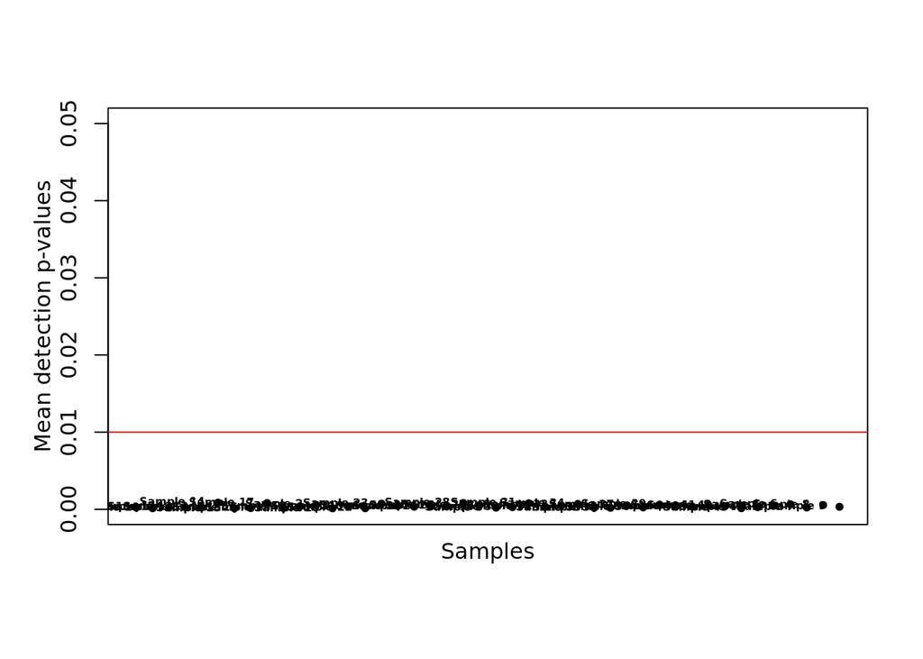

```
## integer(0)
```

```r
#Examine mean detection p-values across all samples to identify any failed samples.
plot(colMeans(detp_minfi), ylim = c(0.00002, 0.05), xaxt = 'n', ann = FALSE, pch = 20, col = "black", cex = 1) +
  mtext(side = 1, line = 0.5, "Samples", font = 1, cex = 1) +
  mtext(side = 2, line = 2, "Mean detection p-values", font = 1, cex = 1) +
  abline(h = 0.01, col = "red") +
  text(colMeans(detp_minfi), labels = AMD_ExtendedRGSet$Sample_Name, cex = 0.5, font = 2, pos = 2)
```

Heiss and Just recommends using the non-specific fluorescence intensities to estimate the background signal, which is a more accurate and stringent method without needing to set an extreme detection p-value cut-off. They imply that this method not only “protect against false-positive findings” but “against false-negative findings as well”. They show that their method calls almost all Y-chromosome probes among males, but classifies most Y-chromosome probes in females as undetected using the 0.01 cut-off, which is the intended outcome as females possess XX chromosomes and should not have any signal detected in Y-chromosomes. They also show similar results detected using the negative control probes, but with a more extreme cut-off and more samples filtered (> 1e-40).

NOTE: No samples above detection p-value of 0.01. All samples passed.

```r
detp_ewastools <- ewastools::detectionP(meth) #Detection p-value distinguishes signal from background noise with a single cut-off.
detp <- as.data.frame(detp_ewastools$detP)
head(detp)[,1:5]
```

```
##             V1            V2            V3            V4           V5
## 1 5.361168e-88  5.204288e-92 7.375519e-131 4.212671e-123 1.016425e-37
## 2 0.000000e+00  0.000000e+00  0.000000e+00  0.000000e+00 0.000000e+00
## 3 7.482801e-20  7.280083e-19  6.448259e-27  5.011001e-19 1.696454e-08
## 4 6.928902e-36  1.822559e-27  1.463483e-40  2.730796e-38 1.150689e-15
## 5 0.000000e+00  0.000000e+00  0.000000e+00  0.000000e+00 0.000000e+00
## 6 0.000000e+00 4.857922e-250  0.000000e+00  0.000000e+00 0.000000e+00
```

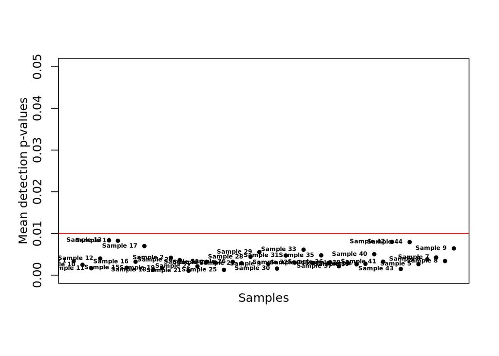

```
## integer(0)
```

```r
colnames(detp) <- colnames(getBeta(AMD_ExtendedRGSet))
rownames(detp) <- meth$manifest$probe_id

#Examine mean detection p-values across all samples to identify any failed samples.
plot(colMeans(detp, na.rm = TRUE), ylim = c(0.00002, 0.05), xaxt = 'n', ann = FALSE, pch = 20, col = "black", cex = 1) +
  mtext(side = 1, line = 0.5, "Samples", font = 1, cex = 1) +
  mtext(side = 2, line = 2, "Mean detection p-values", font = 1, cex = 1) +
  abline(h = 0.01, col = "red") +
  text(colMeans(detp, na.rm = TRUE), labels = colnames(detp), cex = 0.5, font = 2, pos = 2)
```

### Step 3: Beadcount.

For each probe sequence in the 450K array, a median of 14 beads is randomly distributed on the array. Each of these beads contains hundreds of thousands of oligonucleotides. This provides a unique set of internal technical replication on each array. This step is done to remove probes that are not represented by a minimum of 3 beads on the array, which is important to correct for positional effects (i.e. the effects where the same sample in different physical positions on the array could be measured as different methylation levels).

Probes that are not represented by a minimum of 3 beads on the array are designated as NA with the beadcount() function.

NOTE: All samples passed.

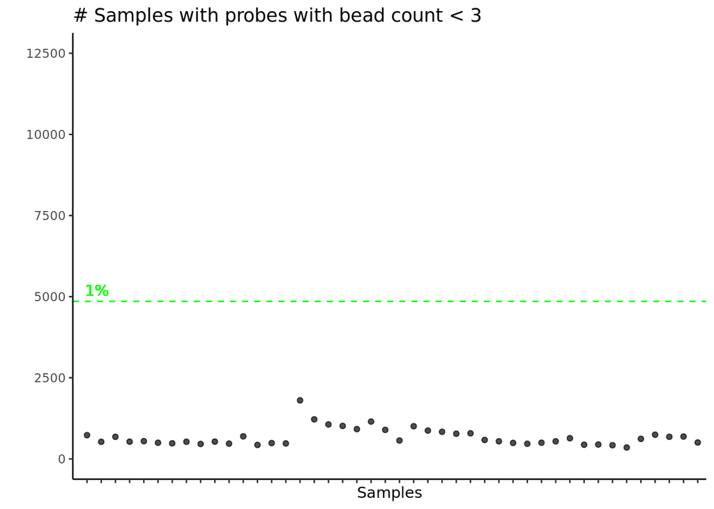

```r
#Calculate the number of samples with bead count <3 for each probe in a matrix of bead count values.
bead <- beadcount(AMD_ExtendedRGSet)
colnames(bead) <- gsub('X', '', colnames(bead))

AMD_samplesheet <- AMD_samplesheet %>% mutate(Beadcount = colSums(is.na(bead)))

AMD_samplesheet %>%
  mutate(Sample_Name = factor(as.character(Sample_Name), levels = Sample_Name)) %>%
  ggplot(aes(x = Sample_Name, y = Beadcount)) +
  geom_point(alpha = 0.7, color = 'black') +
  geom_hline(yintercept = 0.01*nrow(bead), linetype = 'dashed', color = 'green') +
  geom_text(aes(x = 0, y = 0.01*nrow(bead)),
            label = '1%', vjust = -0.5, hjust = -0.5, color = 'green')+
  scale_y_continuous(limits = c(0, 12500), breaks = seq(0, 12500, 2500)) +
  labs(x = 'Samples', y = '', title = '# Samples with probes with bead count < 3') +
  theme_classic() +
  theme(axis.text.x = element_blank())
```

```r
save(detp_minfi, bead, file = "~/KoborLab/kobor_space/kendrix/macular_degeneration/data/AMD_detp_beadcount_QC.RData")
```

### Step 4: Log median intensity of methylated and unmethylated channels.

minfi package provides a simple quality control plot that uses the log median intensity in both the methylated (M) and unmethylated (U) channels. When plotting these two medians against each other, it has been observed that good samples cluster together with higher median intensities, while failed samples tend to separate and have lower median intensities.

NOTE: All samples passed.

```r
AMD_MSet <- preprocessRaw(AMD_ExtendedRGSet) #Get MSet object from RGSet.
head(getMeth(AMD_MSet)[,1:3])
```

```
##            Sample 1 Sample 10 Sample 11
## cg00050873    13702     13026     14553
## cg00212031      459       753       391
## cg00213748     1442      1763      1505
## cg00214611      224       434       119
## cg00455876     3911      4834      5463
## cg01707559      795       802       759
```

```r
head(getUnmeth(AMD_MSet)[,1:3])
```

```
##            Sample 1 Sample 10 Sample 11
## cg00050873     1821      2141      2001
## cg00212031     5111      5494      5486
## cg00213748      257       153       311
## cg00214611     5876      6057      5677
## cg00455876     1178      1320      1431
## cg01707559     7699      8679      8710
```

```r
AMD_QC <- getQC(AMD_MSet)
head(AMD_QC)
```

```
## DataFrame with 6 rows and 2 columns
##                       mMed             uMed
##                  <numeric>        <numeric>
## Sample 1  10.6375305515253 11.3415188232452
## Sample 10 11.0188956211216 11.4361909954814
## Sample 11 11.1478408936723 11.5401280385821
## Sample 12 10.8811139606751 11.4782640315817
## Sample 13 10.8049376720519 11.2801907922169
## Sample 14 10.9708249013626 11.3426302986784
```

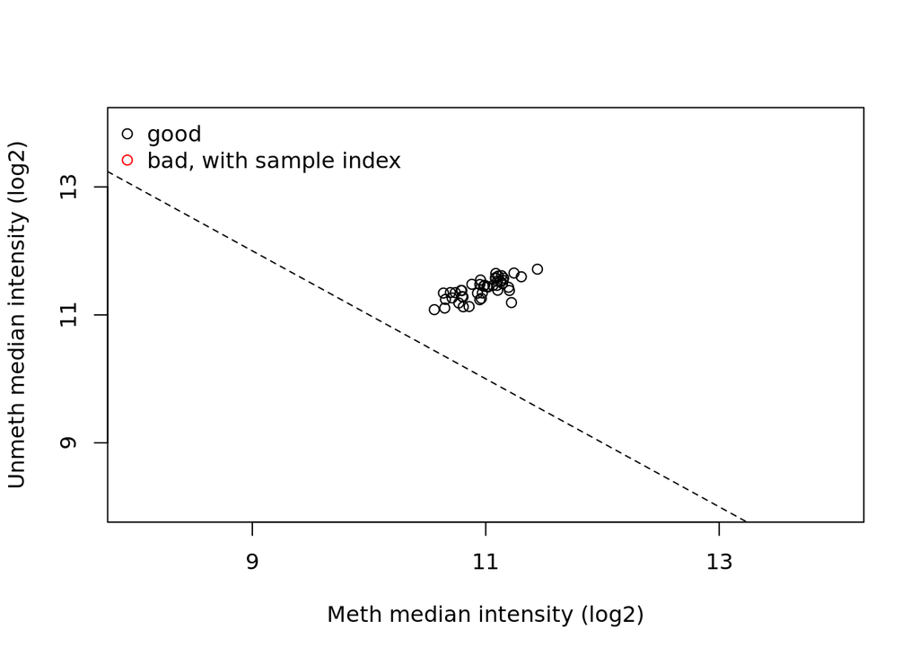

```r
plotQC(AMD_QC)
```

### Step 5: Control metrics.

Quality control metrics are examined to determine the success of the bisulphite conversion and subsequent array hybridisation. This check uses the Illumina’s 636 control probes to assess technical parameters including array staining, extension, hybridization, target removal, specificity, and bisulfite conversion.

NOTE: All samples passed control metrics.

```r
ctrls <- control_metrics(meth)
# A logical vector of passed/failed is returned by sample_failure() which compares all 17 metrics against the thresholds recommended by Illumina.

AMD_sampleInfo$failed <- as.data.frame(sample_failure(ctrls))
table(AMD_sampleInfo$failed) #If AMD_sampleInfo$failed == FALSE, all samples PASS.
```

```
##
## FALSE
##    44
```

```r
failed_control_metrics <- AMD_sampleInfo[AMD_sampleInfo$failed == TRUE, "Sample_Name"] #Check the sample names for the ones that fail control metrics.
failed_control_metrics #No failed samples.
```

```
## factor(0)
## 44 Levels: Sample 1 Sample 10 Sample 11 Sample 12 Sample 13 ... Sample 9
```

```r
#Summary of control metrics.
control_metrics_all <- as.data.frame(ctrls)
control_metrics_all$Sample_Name <- AMD_sampleInfo$Sample_Name
head(control_metrics_all)
```

```
##   Restoration Staining.Green Staining.Red Extension.Green Extension.Red
## 1  0.03074534       165.6038     18.81818        62.96364      13.23746
## 2  0.04477612       128.6500           NA        59.72438      13.03802
## 3  0.04687976             NA           NA        65.51228      12.58561
## 4  0.04408138       110.1176    259.83333        58.45902      13.48349
## 5  0.05071562       761.2381    224.86667        76.97196      11.92087
## 6  0.06167536       896.2500           NA        63.78764      11.68353
##   Hybridization.High.Medium Hybridization.Medium.Low Target.Removal.1
## 1                  1.680178                 2.077765         17.88889
## 2                  1.663601                 2.134143         13.07968
## 3                  1.581086                 2.200758         12.78210
## 4                  1.577832                 2.034192         13.29508
## 5                  1.593910                 2.112461         15.30476
## 6                  1.564947                 2.074236         12.68093
##   Target.Removal.2 Bisulfite.Conversion.I.Green Bisulfite.Conversion.I.Red
```

[output cut: 20 more lines]

```r
sapply(control_metrics_all, function(x) sum(is.na(x)))
```

```
##                  Restoration               Staining.Green
##                            0                           15
##                 Staining.Red              Extension.Green
##                           25                            0
##                Extension.Red    Hybridization.High.Medium
##                            0                            0
##     Hybridization.Medium.Low             Target.Removal.1
##                            0                            0
##             Target.Removal.2 Bisulfite.Conversion.I.Green
##                            0                            0
##   Bisulfite.Conversion.I.Red      Bisulfite.Conversion.II
##                            0                            0
##          Specificity.I.Green            Specificity.I.Red
##                            0                            0
##               Specificity.II        Non.polymorphic.Green
##                            0                            0
##          Non.polymorphic.Red                  Sample_Name
##                            0                            0
```

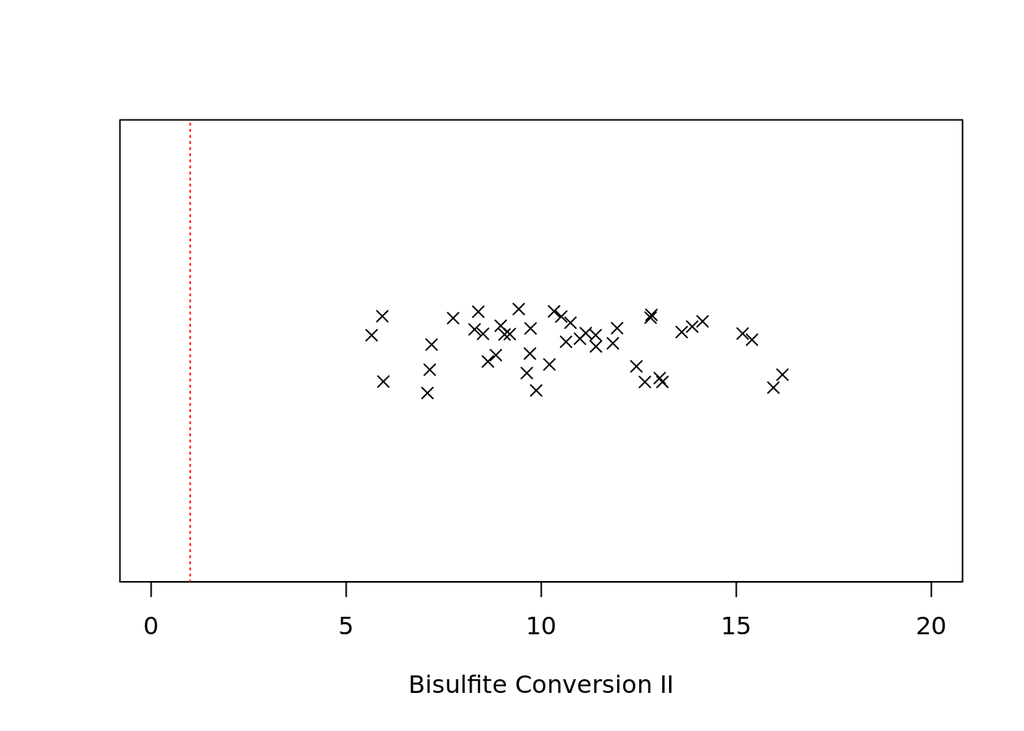

```
## integer(0)
```

```r
stripchart(ctrls$`Bisulfite Conversion II`, method = "jitter", pch = 4, xlab = 'Bisulfite Conversion II', xlim = c(0,20)) +
  abline(v = 1, col = 2, lty = 3) +
  text(ctrls$`Bisulfite Conversion II`[ctrls$`Bisulfite Conversion II` < 1], 1.2, labels = ctrls$Sample_Name[ctrls$`Bisulfite Conversion II` < 1], srt = 45)
```

or

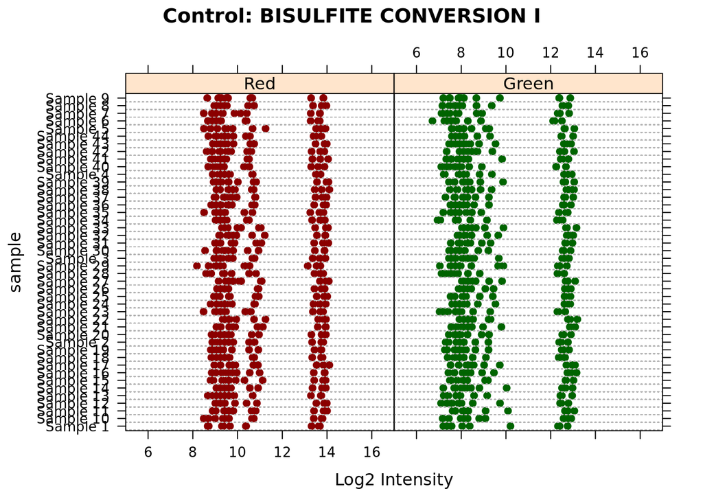

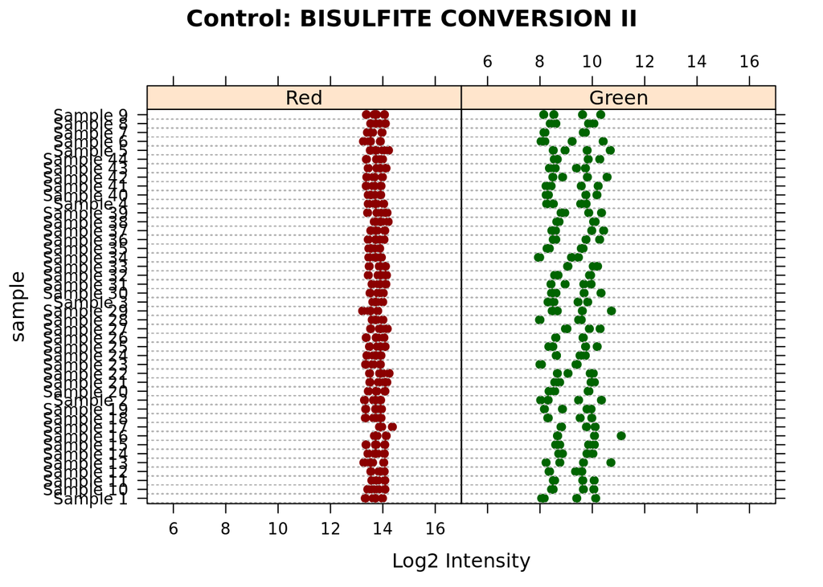

```r
controlStripPlot(AMD_ExtendedRGSet, controls = c("BISULFITE CONVERSION I", "BISULFITE CONVERSION II"))
```

### Step 6: Contamination check.

The 450K BeadChip also features 65 control probes which assay highly-polymorphic single nucleotide polymorphisms (SNPs) rather than DNA methylation. These are included on the array to allow sample quality control to check for relatedness between individuals and enable the detection of potential sample mix-ups. The signal from these probes is expected to cluster into three distinct groups (representing the heterozygous and two homozygous groups). The snp_outliers function however computes the average log odds from the 65 posterior probabilities from a mixture model to capture how irregular the SNP betas are, i.e. how much they deviate from the ideal trimodal distribution. Although these are not DNA methylation signals, they could be used to provide an indication of the degree of technical variance between samples.

NOTE: All samples passed.

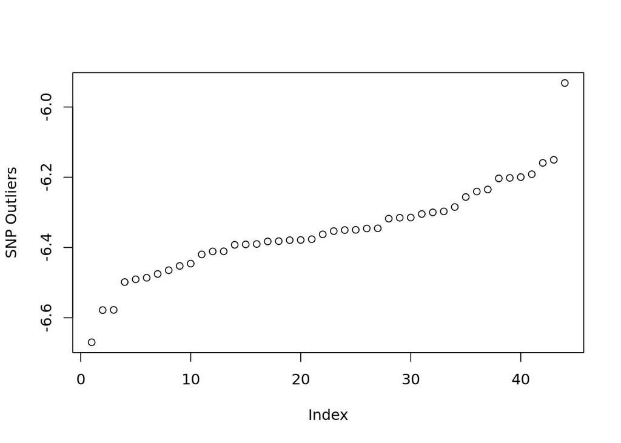

```r
#While ewastools implements the LOESS normalization (Heiss and Brenner, 2015), the developers of the package says not use the normalization "as it does little to protect against batch effects but can result in the removal of genuine biological signal". They recommend to adjust for relevant technical covariates in regression models later.

beta <- dont_normalize(meth)

#Pulling SNP probes.
snps <- meth$manifest[probe_type == "rs", index]
snps <- beta[snps,]

#These SNPs are then used as input for call_genotypes(). This function estimates the parameters of a mixed model consisting of three beta distributions representing one heterozygous and the two homozygous genotypes. There is also a fourth component, shown as a uniform distribution that represents outliers. The functions returns posterior probabilities used for soft classification.
#In simple words, we are determining the probability for every SNP whether they belong to 1 of 4 different distributions - 3 of which correspond to the 3 expected genotypes (AA, AB, BB), and the 4th distribution corresponds to outside/in-between these expected genotype distributions. SNPs with a higher probability of belonging to this 4th distribution indicate mixing between more than one genotype.

#Fit mixed model to call genotypes.
genotypes_called <- call_genotypes(snps, learn = T)

#Call genotype clusters.
AMD_samplesheet <- AMD_samplesheet %>%
  mutate(genotype_cluster = as.factor(enumerate_sample_donors(genotypes_called)))

#Examine probability outlier.
plot(snp_outliers(genotypes_called) %>% sort, ylab = "SNP Outliers")
```

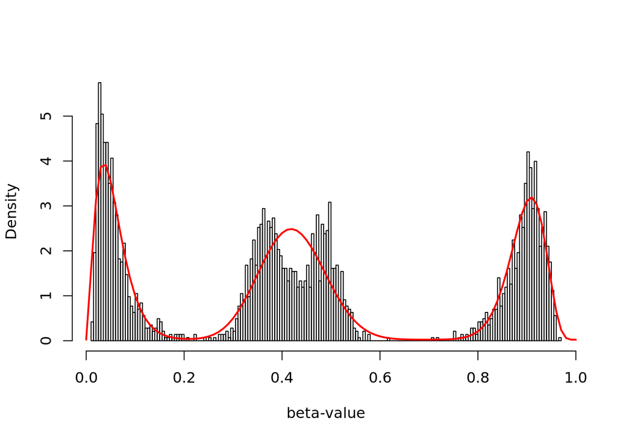

```r
#Overall distribution of the genotypes.
ewastools:::mxm_(genotypes_called)
```

We see 3 peaks, corresponding to 3 possible genotypes.

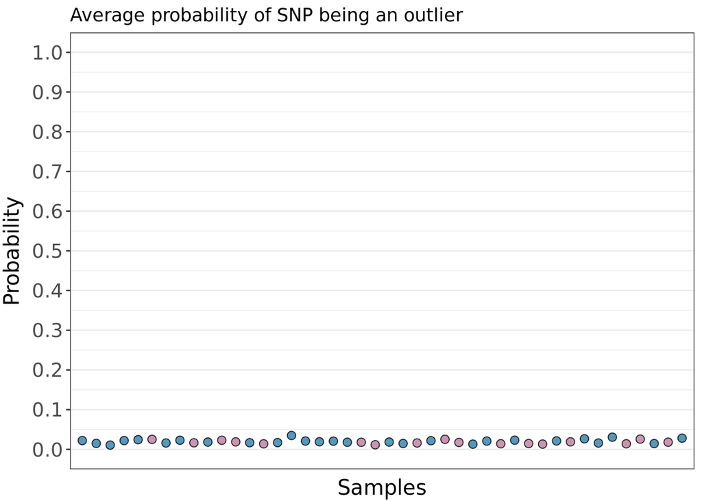

```r
#Check the average probability of SNP not belonging to any of the 3 genotypes (coloured by Sex).
AMD_samplesheet <- AMD_samplesheet %>%
  mutate(Prob_SNP_outlier = colMeans(genotypes_called$outliers, na.rm = T),
         Prob_SNP_outlier_Logodds = snp_outliers(genotypes_called))

  ggplot(AMD_samplesheet, aes(x = Sample_Name, y = Prob_SNP_outlier, fill = Sex)) +
  geom_point(shape = 21, size = 2.5, alpha = 0.8, col = "black") +
  scale_fill_manual(values = c("#bd7b9f", "#2c7dab")) +
  labs(x = 'Samples', y = "Probability",
       title = 'Average probability of SNP being an outlier') +
  theme_bw() +
  theme(axis.text.x = element_text(size = 14),
        axis.text.y = element_text(size = 14),
        axis.title.x = element_text(size = 15, vjust = -0.3),
        axis.title.y = element_text(size = 15, vjust = 2),
        legend.position = "none") +
  scale_y_continuous(limits = c(0, 1), breaks = seq(0, 1, 0.1)) +
  scale_x_discrete(breaks = NULL, expand = c(0.02, 0.02))
```

The Y-axis denotes the average probability of SNP being an outlier. No sample appears to be > 0.1 probability, indicating that there is minimal probability of the presence of outlier.

```r
#Look at the raw distribution
snp_betas <- getSnpBeta(AMD_ExtendedRGSet)
snp_betas_melt <- t(snp_betas) %>% as_tibble %>% mutate(Sample_Name = colnames(snp_betas)) %>%
  left_join(AMD_samplesheet %>% select(Sample_Name, Sex), by = 'Sample_Name') %>%
  gather(key = 'SNP', value = 'Beta', -Sample_Name, -Sex)
```

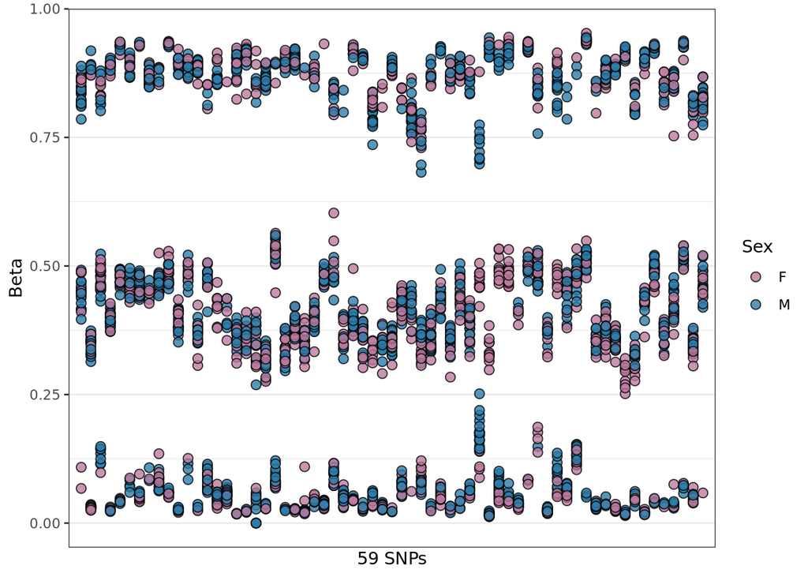

```r
ggplot(snp_betas_melt, aes(x = SNP, y = Beta, fill = Sex)) +
  geom_point(shape = 21, size = 2.5, alpha = 0.8, col = "black") +
  scale_fill_manual(values = c("#bd7b9f", "#2c7dab")) +
  labs(x = '59 SNPs') + theme_bw() + theme(axis.text.x = element_blank()) +
  theme_bw() +
  theme(axis.text.x = element_blank()) +
  scale_x_discrete(breaks = NULL, expand = c(0.02, 0.02))
```

### Step 7: Data linkage errors and Sample relations detection.

omicsPrint (Van Iterson et al. 2018) is a package developed to detect data linkage errors through inspecting sample relations in multiple omics studies. Included with the package is the hm450.manifest.pop.GoNL data, which stores SNP probe information in a GRanges class object. This is then used to create a subset of the beta values for genotyping. The function beta2genotype() then genotypes the observations by measuring homozygous or heterozygous alleles at these SNP probes. Lastly alleleSharing() assesses the relationships between different individuals, which can be unrelated, twins, or identical. The results can then be visualised using the inferRelations() function. In the data with sample relationships, this would be shown in the above graph as green or black clusters (Van Iterson et al. 2018). It is important to carry out this type of visualization before probe-filtering as otherwise the genotyping will be based on very few SNPs.

NOTE: No mismatches found.

```r
data(hm450.manifest.pop.GoNL)

betas.swan <- getBeta(AMD_ExtendedRGSet)

cpgs <- names(hm450.manifest.pop.GoNL[mcols(hm450.manifest.pop.GoNL)$MASK.snp5.EAS])
cpgs <- na.omit(match(cpgs, rownames(betas.swan)))
omicsBetas <- betas.swan[cpgs,]
omicsBetas[1:10, 1:2]
```

```
##              Sample 1  Sample 10
## cg08477687 0.15064562 0.57708628
## cg00645010 0.05583976 0.06016167
## cg11422233 0.07789995 0.07780564
## cg06402284 0.04116505 0.07233649
## cg01551879 0.04928504 0.05166097
## cg20788133 0.66539440 0.68896612
## cg09139287 0.49239130 0.31366692
## cg23100540 0.17080388 0.13082796
## cg23999112 0.70067114 0.74516195
## cg01062849 0.82885375 0.78417470
```

```r
dnamCalls <- beta2genotype(omicsBetas, assayName = "exprs")
dim(dnamCalls)
```

```
## [1] 597  44
```

```r
dnamCalls[1:10, 1:2]
```

```
##            Sample 1 Sample 10
## cg19405842        2         1
## cg01296877        3         1
## cg21783012        1         2
## cg26422465        1         2
## cg00345083        3         2
## cg15075357        2         3
## cg18285337        2         3
## cg02890259        2         3
## cg15600437        2         2
## cg25593194        3         2
```

```r
omicsData <- alleleSharing(dnamCalls, verbose = TRUE)
```

```
## Hash relations
```

```
## Pruning 597 SNPs ...
```

```
## 0 SNPs removed because of low call rate!
```

```
## 0 samples removed because too few SNPs called!
```

```
## Using 597 polymorphic SNPs to determine allele sharing.
```

```
## Running `square` IBS algorithm!
```

```
## 45 of 990 (4.55%) ...
```

```r
mismatches <- inferRelations(omicsData)
```

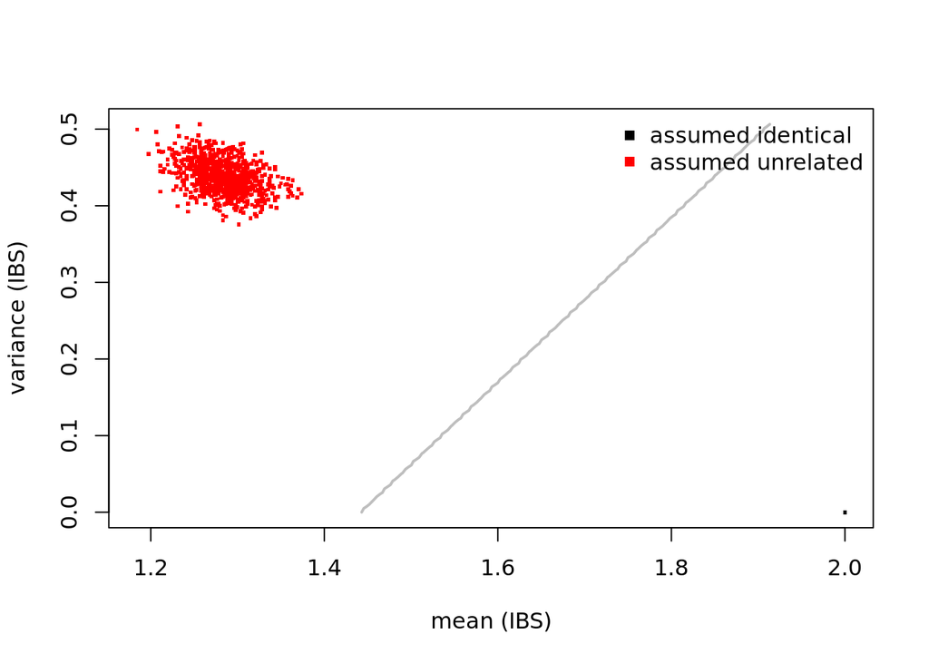

```r
dim(mismatches)
```

```
## [1] 0 6
```

### Step 8: Sample identity.

Hierarchical clustergram across all samples cluster similar samples together while samples that are different from all the other samples are pulled down as outliers.

NOTE: No obvious sample that is pulled down as outlier.

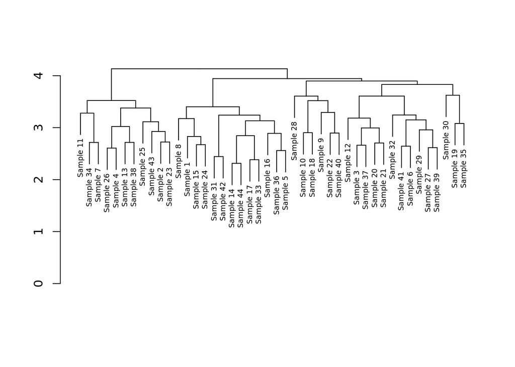

```r
#Use SNP probes to infer identity and see how they cluster.
snp_betas <- getSnpBeta(AMD_ExtendedRGSet)

identity_dendo <- dist(t(snp_betas))
clust <- hclust(identity_dendo)
dendo <- as.dendrogram(clust)

dendo %>% dendextend::set("labels_cex", 0.6) %>%
  hang.dendrogram %>% plot()
```

### Step 9: Outlier detection.

The outlyx function takes any beta matrix (preferably raw) and will identify any samples that are inconsistent with the rest of the data. From the plot, we can observe that any data points that fall into the red squares are indeed outlying and should be removed from analysis.

To confirm the previous identity dendrogram with no obvious outliers, I run the chunk below to see if there are any sample that falls within the two red squares in the plot.

NOTE: No samples fall into the red squares, so no outlier confirmed.

```r
betas.swan <- getBeta(AMD_ExtendedRGSet)
detout <- outlyx(betas.swan)
```

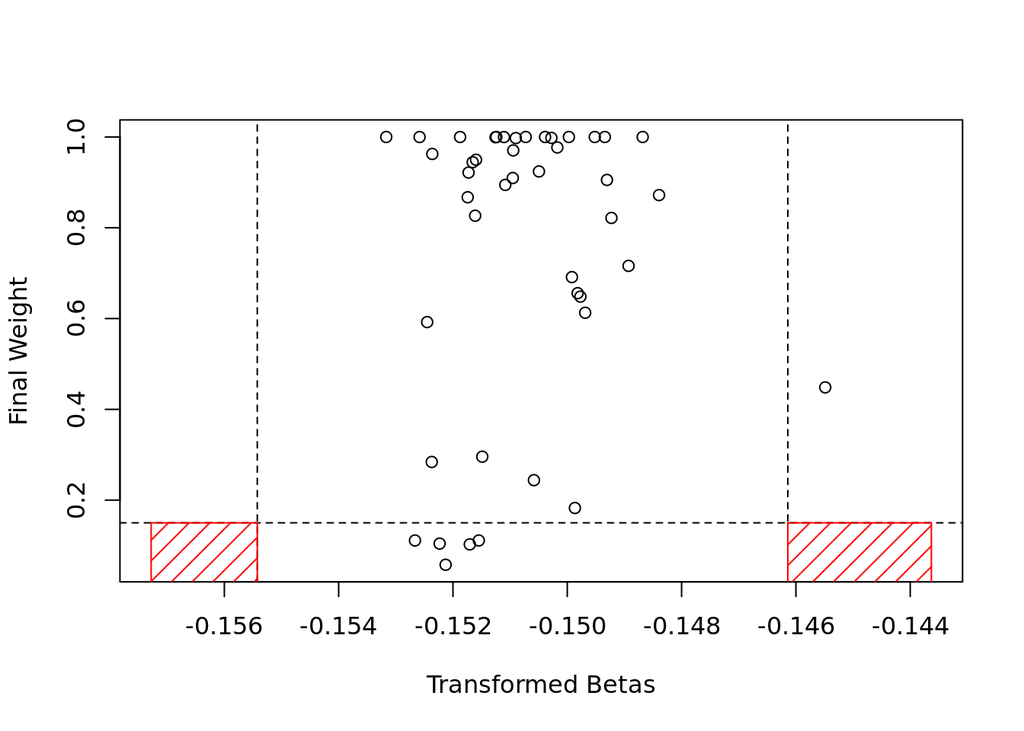

```r
detout$Sample_Name <- rownames(detout)
detout[which(detout$outliers == T),]
```

```
## [1] iqr         mv          outliers    Sample_Name
## <0 rows> (or 0-length row.names)
```

### Step 10: Sex check.

minfi has a sex predictor function that uses the median values of measurements on the X and Y chromosomes respectively. If yMed - xMed is less than cutoff of -2, the sample is predicted as female; otherwise it is predicted as male.

```r
#Get MSet object.
AMD_MSet <- preprocessRaw(AMD_ExtendedRGSet)

#Sex prediction using minfi's getSex() function.
AMD_gRSet <- mapToGenome(AMD_MSet) #Convert to GenomicMethylSet object.
predSex <- getSex(AMD_gRSet)
head(predSex)
```

```
## DataFrame with 6 rows and 3 columns
##                       xMed             yMed predictedSex
##                  <numeric>        <numeric>  <character>
## Sample 1    12.08015127114 12.2494097548417            M
## Sample 10 12.2550285396274 12.4141363144996            M
## Sample 11 12.3826240265749 12.5400006922142            M
## Sample 12 12.2884335395868 12.4617801274941            M
## Sample 13 12.1611318829843 12.3721820668771            M
## Sample 14 12.8814007851121 8.92777492058433            F
```

```r
#Compare to Sex from metadata.
AMD_samplesheet$Sex <- as.factor(AMD_samplesheet$Sex)
predSex$predictedSex <- as.factor(predSex$predictedSex)
all.equal(AMD_samplesheet$Sex, predSex$predictedSex) #TRUE.
```

```
## [1] TRUE
```

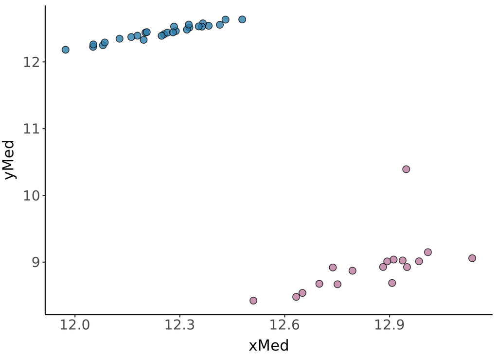

```r
#Plot predicted sex against reported sex from metadata.
predictedSex <- as.data.frame(predSex)
ggplot(predictedSex, aes(x = xMed, y = yMed, fill = AMD_samplesheet$Sex)) +
  geom_point(shape = 21, size = 3, alpha = 0.8, col = "black") +
  scale_fill_manual(values = c("#bd7b9f", "#2c7dab")) +
  theme_classic() +
  theme(axis.text.x = element_text(size = 14),
        axis.text.y = element_text(size = 14),
        axis.title.x = element_text(size = 15, vjust = -0.3),
        axis.title.y = element_text(size = 15, vjust = 2),
        legend.position = "none")
```

The sex of the samples cluster accordingly.

ewastools has a similar sex predictor function that computes for each sample the average total intensities of all probes targeting either chromosome, X and Y respectively (There are 11,232 probes that target the X chromosome and 413 probes that target the Y chromosome). This function exploits the natural difference in allosomal (sex) copy number (with females having more copy number than males) and the fact that total intensity (U + M) is sensitive to copy number variation to detect sex mismatches. The threshold to discriminate between both sexes is determined by the Hodges-Lehmann estimator (i.e. median of all pairwise male/female averages) for X and Y chromosomes separately. The dotted lines in the figure below represent the Hodges-Lehman estimators separating the male and female cluster centres. The male samples should cluster in the top left quadrant while the female samples should cluster in the bottom right quadrant. The samples that fall in the top right and bottom left quadrants are considered “unclear” (Heiss & Just 2018).

It is suggested that this approach is more robust than minfi’s getSex() function due to its potential to detect sex mismatches and allosomal outliers.

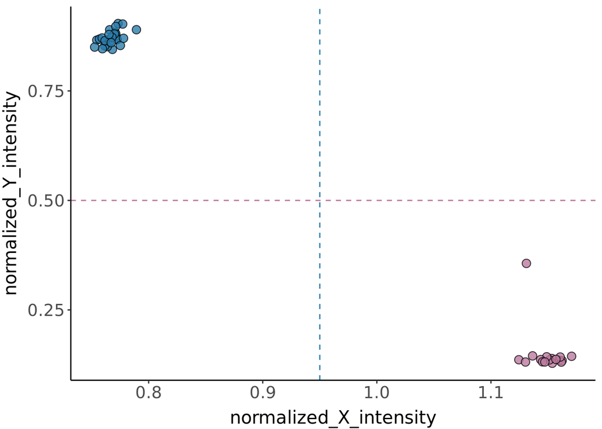

```r
#Sex prediction using ewastools' check_sex() function.
predicted_sex <- check_sex(meth)
AMD_samplesheet <- AMD_samplesheet %>% mutate(normalized_X_intensity = predicted_sex$X,
                        normalized_Y_intensity = predicted_sex$Y)

#Sex plot.
ggplot(AMD_samplesheet, aes(x = normalized_X_intensity, y = normalized_Y_intensity, fill = Sex)) +
  geom_point(shape = 21, size = 3, alpha = 0.8, col = "black") + theme_classic() +
  scale_fill_manual(values = c("#bd7b9f", "#2c7dab")) +
  geom_text_repel(data = AMD_samplesheet %>% filter(Sex == 'M', normalized_X_intensity > 0.95,
                                         normalized_Y_intensity < 0.5),
                  aes(label = Sample_Name), size = 3, force = 15, nudge_x = -0.1, nudge_y = -0.1) +
  geom_hline(yintercept = 0.5, linetype = 'dashed', col = '#bd7b9f') +
  geom_vline(xintercept = 0.95, linetype = 'dashed', col = '#2c7dab') +
  theme(axis.text.x = element_text(size = 14),
        axis.text.y = element_text(size = 14),
        axis.title.x = element_text(size = 15, vjust = -0.3),
        axis.title.y = element_text(size = 15, vjust = 2),
        legend.position = "none")
```

This second check confirms no sex mismatches in the samples.

### Step 11: Post sample filtering PCA.

Code from Nicole Gladish, Rachel Edgar and Sumaiya Islam.

Location: ~/KoborLab/kobor_space/shared_coding_resource/PCA Code.Rmd

```r
betas.swan <- getBeta(AMD_ExtendedRGSet) #Essentially use your mvalue matrix.
meta <- pData(AMD_ExtendedRGSet)
PCA_full <- princomp(na.omit(betas.swan)) #You can't have NAs in your dataframe - make sure to either remove probes with a lot of NAs and/or have imputed values. Can run na.omit but depending on the stage of pre-processing, could result in a lot of probes to be removed and a very inaccurate PCA.
Loadings <- as.data.frame(unclass(PCA_full$loadings))
vars <- PCA_full$sdev^2
Importance <- vars/sum(vars)
adjust <- 1-Importance[1]
pca_adjusted <- Importance[2:length(Importance)]/adjust
pca_df <- data.frame(adjusted_variance = pca_adjusted, PC = seq(1:length(pca_adjusted)))

#Restructure meta so that variables are in the appropriate format - categorical variables (sex is commonly labelled as 0 and 1) are factors and not numeric for example.

colnames(meta)[6] <- "Sentrix_Position"
colnames(meta)[7] <- "Sentrix_ID"

meta$Sentrix_ID <- as.factor(meta$Sentrix_ID)
meta$Sentrix_Position <- as.factor(meta$Sentrix_Position)
meta$Sex <- as.factor(meta$Sex)
meta$Sample_Group <- as.factor(meta$Sample_Group)
meta$Age <- as.numeric(meta$Age)

colnames(meta) #Obtain the column numbers to include.
```

```
## [1] "Sample_Name"      "Sample_Group"     "Sex"              "Age"
## [5] "Tissue"           "Sentrix_Position" "Sentrix_ID"       "Basename"
## [9] "filenames"
```

```r
meta_categorical <- data.frame(meta[, c(2,3,6,7)])  #Input column numbers in meta that contain categorical variables.
meta_continuous <- data.frame(meta[,4])  #Input column numbers in meta that contain continuous variables.
colnames(meta_categorical) #Write the line below to ensure you're changing the names of your variables in the right order.
```

```
## [1] "Sample_Group"     "Sex"              "Sentrix_Position" "Sentrix_ID"
```

```r
colnames(meta_categorical) <- c("Disease state", "Sex", "Position", "Chip")
colnames(meta_continuous)
```

```
## [1] "meta...4."
```

```r
colnames(meta_continuous) <- c("Age")

Order <- c(seq(1:sum(ncol(meta_categorical), ncol(meta_continuous))))
Num <- 16 #This number will depend on your dataset - if you only have 6 samples, you should probably only show 5 PCs or less.
```

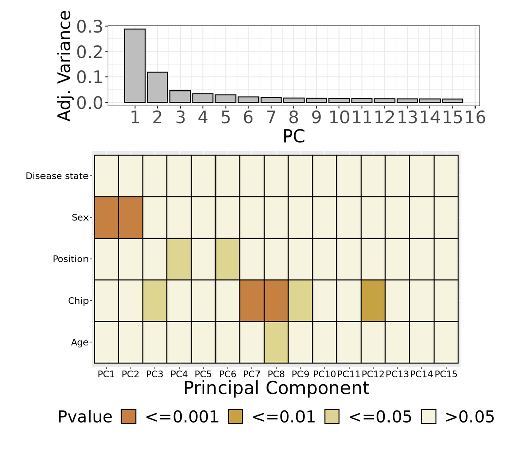

```r
#Run PCA.
source("~/KoborLab/kobor_space/kendrix/R_Functions/heat_scree_plot.R", local = knitr::knit_global())
heat_scree_plot(Loadings, Importance, Num, Order)
```

## Normalisation

### Step 1: Visualise pre-normalised distribution of beta values.

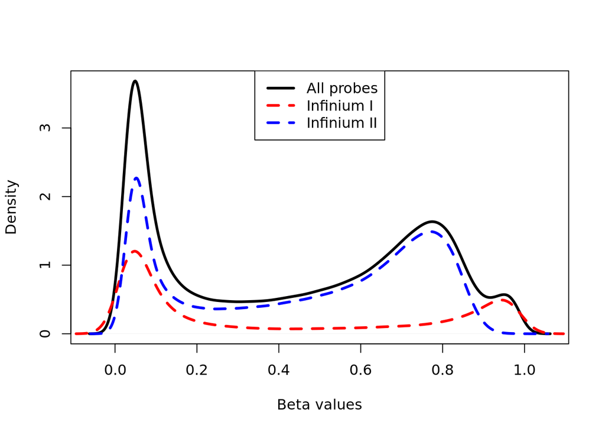

```r
AMD_MSet <- preprocessRaw(AMD_ExtendedRGSet) #Get MSet object from RGSet.
plotBetasByType(AMD_MSet[,1])
```

### Step 2: Perform SWAN normalisation.

Subset-quantile within array normalization (SWAN) (Jovana Maksimovic, Lavinia Gordon, and Alicia Oshlack 2012) is a within-array normalization correction for the technical differences between the Type I and Type II array designs. The algorithm matches the beta-value distributions of the Type I and Type II probes by applying a within-array quantile normalization separately for different subsets of probes (divided by CpG content).

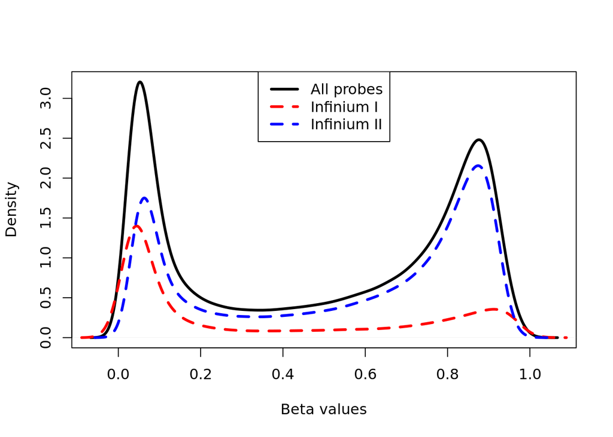

```r
AMD_MSet <- preprocessRaw(AMD_ExtendedRGSet) #Get MSet object from RGSet.

#SWAN uses a random subset of probes to do the between array normalization. In order to achive reproducible results, the seed needs to be set using set.seed.
set.seed(100)

#Perform SWAN normalisation.
AMD_MSet.swan <- preprocessSWAN(AMD_ExtendedRGSet, mSet = AMD_MSet)

#Plot to visualise post-normalisation distribution.
plotBetasByType(AMD_MSet.swan[,1])
```

```r
save(AMD_MSet.swan, file = "~/KoborLab/kobor_space/kendrix/macular_degeneration/data/AMD_MSet.swan.RData")
```

### Step 3: Post-normalisation PCA.

The publication uses SWAN normalisation.

```r
#Load the normalised beta matrix of choice.
betas.swan <- getBeta(AMD_MSet.swan)
meta <- as.data.frame(pData(AMD_MSet.swan))

identical(rownames(meta), colnames(betas.swan)) #TRUE.
```

```
## [1] TRUE
```

```r
PCA_full <- princomp(betas.swan) #You can't have NAs in your dataframe - make sure to either remove probes with a lot of NAs and/or have imputed values. Can run na.omit but depending on the stage of pre-processing, could result in a lot of probes to be removed and a very inaccurate PCA.
Loadings <- as.data.frame(unclass(PCA_full$loadings))
vars <- PCA_full$sdev^2
Importance <- vars/sum(vars)
adjust <- 1-Importance[1]
pca_adjusted <- Importance[2:length(Importance)]/adjust
pca_df <- data.frame(adjusted_variance = pca_adjusted, PC = seq(1:length(pca_adjusted)))

#Restructure meta so that variables are in the appropriate format - categorical variables (sex is commonly labelled as 0 and 1) are factors and not numeric for example.

colnames(meta)[6] <- "Sentrix_Position"
colnames(meta)[7] <- "Sentrix_ID"

meta$Sentrix_ID <- as.factor(meta$Sentrix_ID)
meta$Sentrix_Position <- as.factor(meta$Sentrix_Position)
meta$Sex <- as.factor(meta$Sex)
meta$Sample_Group <- as.factor(meta$Sample_Group)
meta$Age <- as.numeric(meta$Age)

colnames(meta) #Obtain the column numbers to include.
```

```
## [1] "Sample_Name"      "Sample_Group"     "Sex"              "Age"
## [5] "Tissue"           "Sentrix_Position" "Sentrix_ID"       "Basename"
## [9] "filenames"
```

```r
meta_categorical <- data.frame(meta[, c(2,3,6,7)])  #Input column numbers in meta that contain categorical variables.
meta_continuous <- data.frame(meta[,4])  #Input column numbers in meta that contain continuous variables.
colnames(meta_categorical) #Write the line below to ensure you're changing the names of your variables in the right order.
```

```
## [1] "Sample_Group"     "Sex"              "Sentrix_Position" "Sentrix_ID"
```

```r
colnames(meta_categorical) <- c("Disease state", "Sex", "Position", "Chip")
colnames(meta_continuous)
```

```
## [1] "meta...4."
```

```r
colnames(meta_continuous) <- c("Age")

Order <- c(seq(1:sum(ncol(meta_categorical), ncol(meta_continuous))))
Num <- 16 #This number will depend on your dataset - if you only have 6 samples, you should probably only show 5 PCs or less.
```

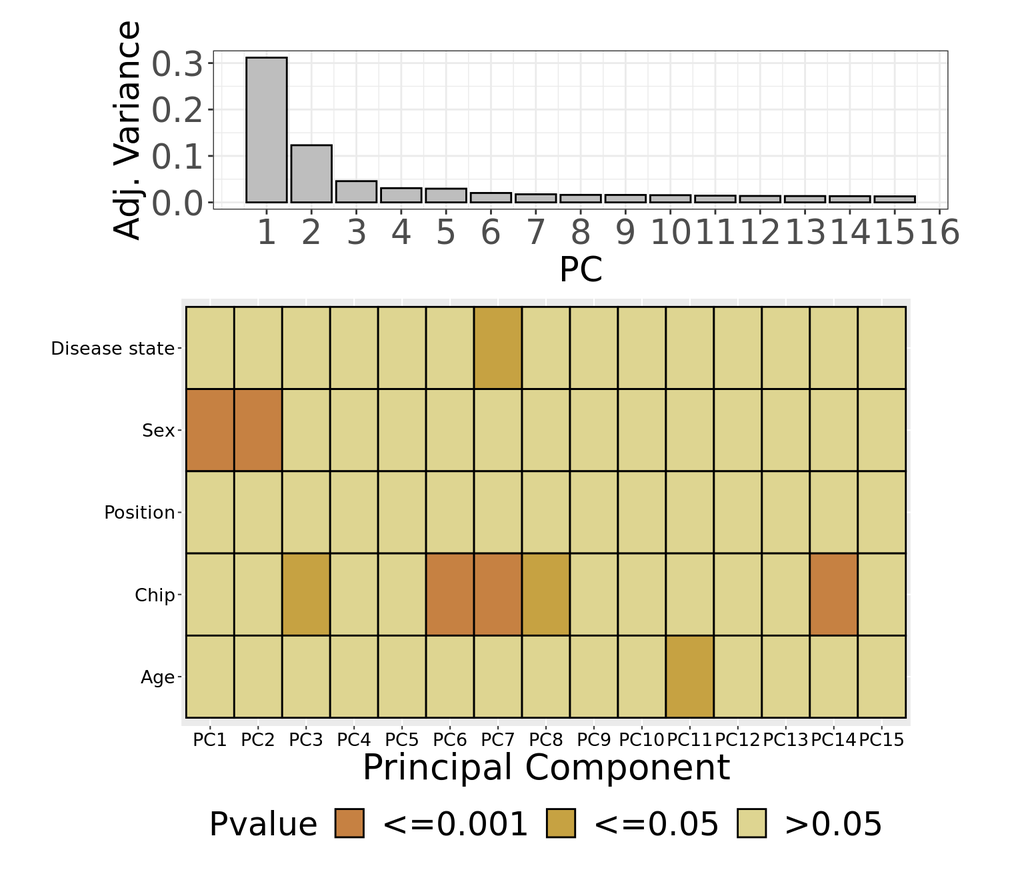

```r
#Run PCA.
source("~/KoborLab/kobor_space/kendrix/R_Functions/heat_scree_plot.R", local = knitr::knit_global())
heat_scree_plot(Loadings, Importance, Num, Order)
```